# Report: act_report

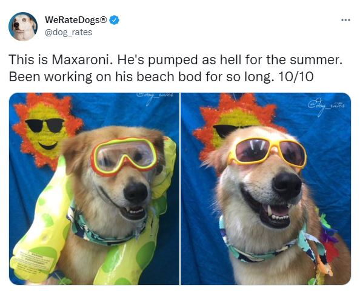

*Fig.1: Tweet about Maxaroni via WeRateDogs*

I was interested in knowing the distributions of retweet and favourite counts across the three years 2015, 2016 and 2017, as well as the distribution across the months of each year in the master dataset. It was important to also know the percentage of the algorithm predictions p1, p2 and p3 that were actually dogs.

On the distribution of retweet count across the three years, when the sum of retweet count was computed for each of the years, it was observed that 2016 recorded the highest retweet count and 2015 recorded the lowest retweet count. However, when the mean distribution for each year was computed and compared to the other, while 2015 still recorded the lowest mean distribution, 2017 now recorded the highest mean distribution. For monthly distribution across the three years, in November 2015, the least mean retweet count of 540 was recorded, with the highest average retweet count of 7683 recorded in August 2017. In total, the are 22 months across the three years in the master dataset.

The trend for the sum of the distribution of favourite count was highest in 2017 and least in 2015. This trend was also observed when the average distributions were computed. The least average favourite count of 2499 was recorded in 2015 while the highest average favourite count of 23984 was recorded in 2017. In August 2017, the highest average monthly favourite count of 36643 was recorded and the lowest average of 1238 was recorded in November 2015.

On the percentage of the algorithm predictions which were actually dogs, it was determined that 60.30 % of the algorithm predictions p1, p2 and p3 were truly dog, while 15.40 % of the predictions across all three algorithms were not dogs. The remaining 24.30 % were a mix of predictions where either one or two of the predictions were dog and the remainder not a dog and vice versa.

The scatter plot visualization below sort to know if there was any correlation between retweet count and favourite count, and if there was, what kind was it? As the plot revealed, retweet count and favourite count were positively correlated, which was strongest when retweet count was between 0 and 20000, and favourite count was between 0 and 50000.

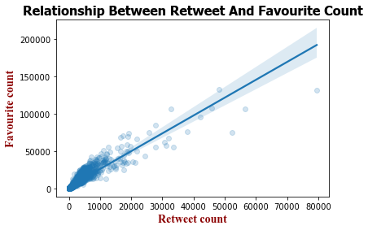